## **Bridled nail-tail wallaby**

### Blamed on cats

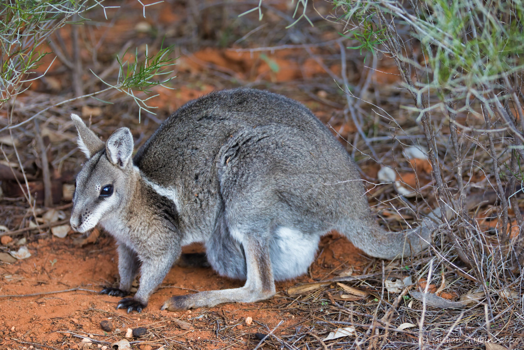

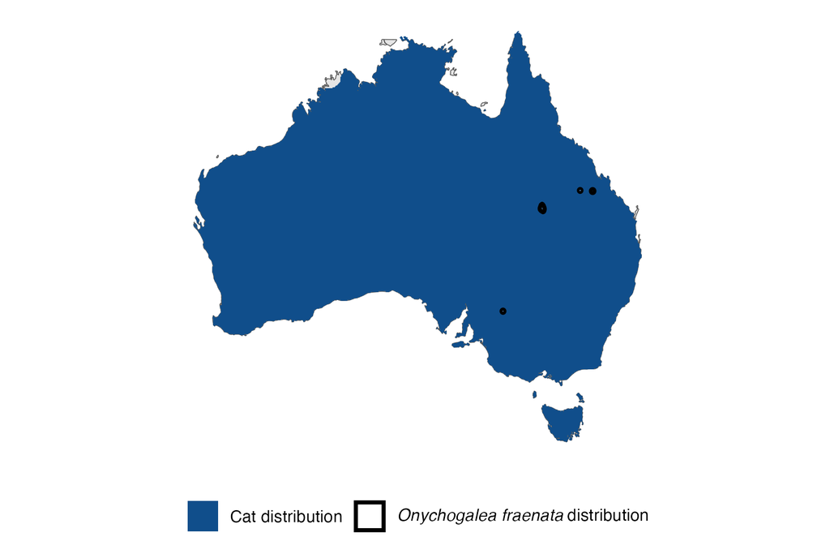

IUCN status: **Vulnerable**

EPBC Predator Threat Rating: **Very high**

IUCN claim: *“The species is threatened by introduced predators, the Red Fox and feral Cat especially”*

### Studies in support

Cats hunt wallabies (Horsup & Evans 1993; Fisher 1999; Fisher et al. 2001; Augusteyn et al. 2022). Wallabies were last confirmed in the Western Division of NSW 20-70 years after cats arrived (Wallach and Lundgren 2025).

### Studies not in support

No correlation was found between cat and wallaby abundance (Augusteyn et al. 2022). No evidence was found that killing cats promotes wallaby abundance (Augusteyn et al. 2022). Cats were not among predators of reintroduced, predator-inexperienced wallabies (Hayward et al. 2012).

### Is the threat claim evidence-based?

No studies were found linking cats to nail-tail wallaby population trends.

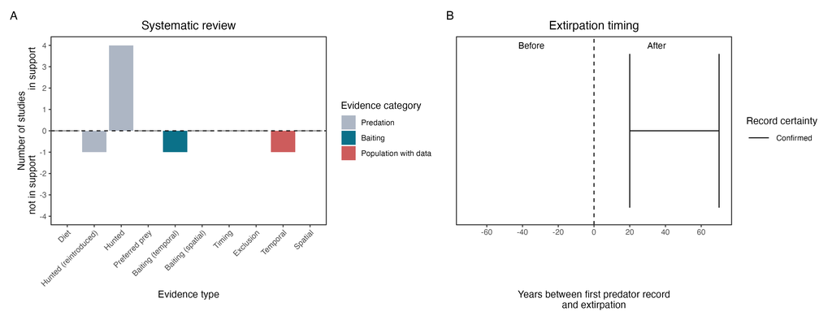

**Evidence linking *Onychogalea fraenata* to cats.** **A.** Systematic review of evidence for an association between *Onychogalea fraenata* and cats. Positive studies are in support of the hypothesis that cats contribute to the decline of *Onychogalea fraenata*, negative studies are not in support. Predation studies include studies documenting hunting or scavenging; baiting studies are associations between poison baiting and threatened mammal abundance where information on predator abundance is not provided; population studies are associations between threatened mammal and predator abundance. Gold borders indicate studies that meet qualities of scientific rigour. **B.** Last records of extirpated populations relative to earliest local records of cats. Error bars show minimum and maximum extinction intervals. Predator arrival records were digitized from Abbott 2008. See methods section in Wallach and Lundgren 2025 for details on evidence categories.

### References

Abbott, The spread of the cat, Felis catus, in Australia: re-examination of the current conceptual model with additional information. Conservation Science Western Australia 7 (2008).

Augusteyn, J., McCarthy, M.A., Robley, A., Pople, A., Nolan, B., Hemson, G., Melzer, R., Richards, S. and Dinwoodie, A., 2022. Bringing back the endangered bridled nail-tailed wallaby at Taunton National Park (Scientific) through effective predator control. Wildlife Research, 49(4), pp.382-398.

EPBC. (2015) Threat Abatement Plan for Predation by Feral Cats. Environment Protection and Biodiversity Conservation Act 1999, Department of Environment, Government of Australia. (Table A1).

Fisher, D., 1999. Behavioural ecology and demography of the bridled nailtail wallaby, Onychogalea fraenata. PhD Thesis, School of Biological Sciences, The University of Queensland.

Fisher, D.O., Blomberg, S.P. and Hoyle, S.D., 2001. Mechanisms of drought-induced population decline in an endangered wallaby. Biological Conservation, 102(1), pp.107-115.

Hayward, M.W., L’Hotellier, F., O’Connor, T., Ward-Fear, G., Cathcart, J., Cathcart, T., Sephens, J., Stephens, J., Herman, K. and Legge, S., 2012, January. Reintroduction of bridled nailtail wallabies beyond fences at Scotia Sanctuary-Phase 1. In Proceedings of the Linnean Society of New South Wales (Vol. 134).

Horsup, A. and Evans, M., 1993. Predation by feral cats, Felis catus, on an endangered marsupial, the bridled nailtail wallaby, Onychogalea fraenata. Australian Mammalogy, 16(1), pp.83-84.

IUCN Red List. https://www.iucnredlist.org/ Accessed June 2023

Wallach A.D., Lundgren E.J. (2025) Review of evidence that foxes and cats cause extinctions of Australia’s endemic mammals. BioScience. DOI: 10.1093/biosci/biaf046